# Explore DSM HabitatC hanges

Erin Cain

7/23/2021

This document shows changes in the DSM habitat inputs from the old habitat data to new 2021 `DSMhabitat` release. Each section shows new, old and scaled habitat estimates, describes change and percent change in mean habitat, and explains what caused the habitat change for each river in which habitat acres shifted.

```r
# Fall Run Scales
# SPAWN
# 1 Upper Sac
# 2 Butte
# 3 Clear
# 4 Deer
# 5 Mill
# 6 Feather
# 7 Yuba
# 8 American
# 9 Cosumness
# 10 Mokelumne
# 11 Merced
# 12 Stanislaus
# 13 Tuolumne
# REAR
# 1 Upper Sac
# 2 Butte
# 3 Clear
# 4 Deer
# 5 Mill
# 6 Upper-mid Sac (corridor for above)
# 7 Sutter (corridor for above) is changed below
# 8 Feather
# 9 Yuba
# 10 Lower-mid Sac (corridor for above)
# 11 Yolo (corridor for above) is changed below
# 12 American
# 13 Lower Sac (corridor for above)
# 14 Cosumness
# 15 Mokelumne
# 16 Merced
# 17 Stanislaus
# 18 Tuolumne
# 19 SJ (corridor for Merced, Stan, and Tuolumne)
# here 1-13 are spawning scalars
# 14-n are the rearing scalars
fall_run_scales <- c(1.8615848, 0.5000000,
                     0.5000000, 1.4230370,
                     0.5887938, 2.0000000,
                     0.5034449, 0.5502821,
                     1.6139332, 0.9551340,
                     1.6993421, 0.9627230,
                     0.9959632, 0.5000000,
                     1.8237525, 2.0000000,
                     1.9999999, 2.0000000,
                     2.0000000, 0.9783833,
                     1.5406860, 0.6596480,
                     1.9999994, 1.9999994,
                     0.5000423, 0.6147676,
                     0.6598354, 0.8103934,
                     1.2434156, 1.4492968,
                     0.9347787, 1.6509423,
                     0.5000000, 1.9800862)

spawn_scales <- tibble(watershed = factor(DSMscenario::watershed_labels[c(1, 6, 7, 10, 12, 19, 20,
                                            23, 26, 27, 28, 29, 30)],
                                          levels = DSMscenario::watershed_labels),
                       scales = fall_run_scales[1:13])


rear_scales <- tibble(watershed = factor(c(DSMscenario::watershed_labels[c(1, 6, 7, 10, 12, 16,
                                            19, 20, 21, 23, 24,
                                            26, 27, 28, 29, 30, 31, 17, 22)], "North Delta", "South Delta"),
                     levels = DSMscenario::watershed_labels),
                      scales = fall_run_scales[14:34])
```

## Spawning Habitat

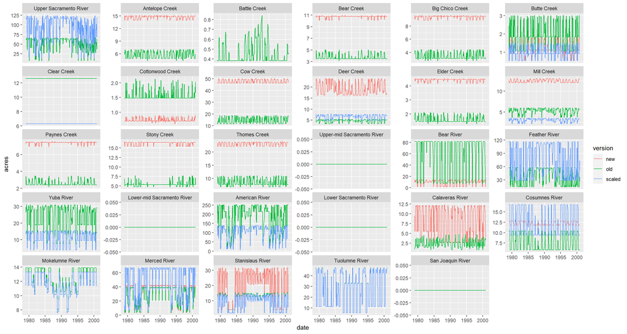

```r
new <- DSMhabitat::fr_spawn %>% DSMhabitat::square_meters_to_acres()
old <- cvpiaData::fr_spawn %>% DSMhabitat::square_meters_to_acres()
spawn <- expand_grid(
  watershed = factor(DSMscenario::watershed_labels,
                     levels = DSMscenario::watershed_labels),
  month = 1:12,
  year = 1979:2000) %>%
  left_join(spawn_scales) %>%
  arrange(year, month, watershed) %>%
  mutate(
    old = as.vector(old),
    new = as.vector(new),
    scaled = old * scales)
spawn %>%
  transmute(watershed, date = ymd(paste(year, month, 1)), old, new, scaled) %>%
  filter(!(watershed %in% c('Sutter Bypass', 'Yolo Bypass'))) %>%
  gather(version, acres, -watershed, -date)  %>%
  ggplot(aes(date, acres, color = version)) +
  geom_line() +
  facet_wrap(~watershed, scales = 'free_y')
```

**Summary Table**: All habitat measures are in acres and rounded to the nearest acre.

```r
change <- spawn %>% group_by(watershed) %>%
  summarise(mean_old_habitat = round(mean(old)),
            mean_new_habitat = round(mean(new)),
            change_in_mean_habitat = round(mean_new_habitat - mean_old_habitat),
            percent_change = round(change_in_mean_habitat/mean_old_habitat * 100),
            percent_change_in_mean_habitat = paste(percent_change, "%")
            ) %>%
  filter(change_in_mean_habitat != 0) %>%
  select(-percent_change)

DT::datatable(change, option=list(columnDefs=list(list(targets=3:5, class="dt-right"))))
```

|  | watershed | mean_old_habitat | mean_new_habitat | change_in_mean_habitat | percent_change_in_mean_habitat |
| --- | --- | --- | --- | --- | --- |
| 1 | Antelope Creek | 6 | 15 | 9 | 150 % |
| 2 | Bear Creek | 4 | 11 | 7 | 175 % |
| 3 | Big Chico Creek | 3 | 9 | 6 | 200 % |
| 4 | Butte Creek | 2 | 1 | -1 | -50 % |
| 5 | Cottonwood Creek | 2 | 1 | -1 | -50 % |
| 6 | Cow Creek | 14 | 48 | 34 | 243 % |
| 7 | Deer Creek | 5 | 19 | 14 | 280 % |
| 8 | Elder Creek | 2 | 4 | 2 | 100 % |
| 9 | Mill Creek | 5 | 12 | 7 | 140 % |
| 10 | Paynes Creek | 3 | 7 | 4 | 133 % |

[output cut: 7 more lines]

#### Explanation of Habitat Changes:

- **Bear River**: Data Updated: Original data used was from `IFIMWUA.xlsx`. Data was updated to `'data-raw/watershed/bear_river/data/updated_bear_river_instream.csv'` also provided by Mark Gard.
- **Butte Creek**: Data Updated: Original data used was from `IFIMWUA.xlsx`. Data was updated to `"data-raw/watershed/data/butte_creek_spring_run_spawning_wua.csv'"` & `"data-raw/watershed/data/butte_creek_steelhead_spawning_wua.csv'"` (Went to the origional report and got additional information)
- **Cottonwood Creek**: QA/QCd original data and redid scaling/wua conversion because initial estimate was too high
- **Cow Creek**: Increased Salmonid habitat extent to include north cow creek
- **Deer Creek**: New HSI derived habitat data
- **Calaveras River** Data Updated: Original data used was from `IFIMWUA.xlsx`. Data was updated to `"data-raw/watershed/calaveras/data/calaveras.csv"`
- **Cosumnes River**: Based on combination of Calaveras and Mokelume Rivers (Change in Calaveras caused change in Cosumnes)
- **Merced River**: Original habitat data was only using already aggregated data from `IFIMWUA.xlsx` (`A18:E48`) but this original data did not have consistent flows across all 3 reaches. Updated data reads in each reach separately and uses an approx function to find habitat for each flow at each reach and then combines all reaches at corresponding flows.
- **Stanislaus River**: Original habitat data was only using already aggregated data from `IFIMWUA.xlsx` (`I4:N60`) which was not scaled by reach length. We updated the data to scale in each reach depending on length by reading in each reach separately, scale habitat in each reach according to reach length, and then adding all reaches together.
- Regional Approx Spawn Changed because Clear was changed to a set value for all flows, changes to Cottonwood and Butte also altered regional approx slightly
  - **Elder Creek**
  - **Mill Creek**
  - **Paynes Creek**
  - **Stony Creek**
  - **Thomes Creek**
  - **Big Chico Creek**
  - **Antelope Creek**
  - **Bear Creek**

## Fry Habitat

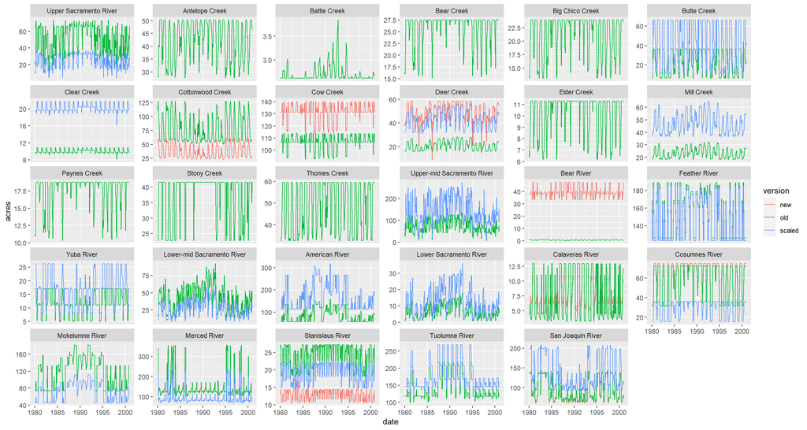

```r
new <- DSMhabitat::fr_fry %>% DSMhabitat::square_meters_to_acres()
old <- cvpiaData::fr_fry %>% DSMhabitat::square_meters_to_acres()
dimnames(old) <- dimnames(new)
fry <- expand_grid(
  watershed = factor(DSMscenario::watershed_labels,
                     levels = DSMscenario::watershed_labels),
  month = 1:12,
  year = 1980:2000) %>%
  left_join(rear_scales) %>%
  arrange(year, month, watershed) %>%
  mutate(
    old = as.vector(old),
    new = as.vector(new),
    scaled = old * scales
    )

fry %>%
  transmute(watershed, date = ymd(paste(year, month, 1)), old, new, scaled) %>%
  filter(!(watershed %in% c('Sutter Bypass', 'Yolo Bypass'))) %>%
  gather(version, acres, -watershed, -date)  %>%
  ggplot(aes(date, acres, color = version)) +
  geom_line() +
  facet_wrap(~watershed, scales = 'free_y')
```

**Summary Table**: All habitat measures are in acres and rounded to the nearest acre.

```r
change <- fry %>% group_by(watershed) %>%
  summarise(mean_old_habitat = round(mean(old)),
            mean_new_habitat = round(mean(new)),
            change_in_mean_habitat = round(mean_new_habitat - mean_old_habitat),
            percent_change = round(change_in_mean_habitat/mean_old_habitat * 100),
            percent_change_in_mean_habitat = paste(percent_change, "%")
            ) %>%
  filter(change_in_mean_habitat != 0, watershed != "Merced River") %>%
  select(-percent_change)

DT::datatable(change, option=list(columnDefs=list(list(targets=3:5, class="dt-right"))))
```

|  | watershed | mean_old_habitat | mean_new_habitat | change_in_mean_habitat | percent_change_in_mean_habitat |
| --- | --- | --- | --- | --- | --- |
| 1 | Cottonwood Creek | 78 | 37 | -41 | -53 % |
| 2 | Cow Creek | 107 | 132 | 25 | 23 % |
| 3 | Deer Creek | 21 | 48 | 27 | 129 % |
| 4 | Bear River | 0 | 40 | 40 | Inf % |
| 5 | Calaveras River | 7 | 8 | 1 | 14 % |
| 6 | Cosumnes River | 58 | 59 | 1 | 2 % |
| 7 | Stanislaus River | 24 | 13 | -11 | -46 % |
| 8 | San Joaquin River | 95 | 94 | -1 | -1 % |

#### Explanation of Habitat Changes:

- **Cottonwood Creek**: QA/QCd original data and redid scaling/wua conversion because initial estimate was too high
- **Cow Creek**: Increased Salmonid habitat extent to include north cow creek
- **Deer Creek**: New HSI derived habitat data
- **Bear River**: Data Updated: Original data used was from `IFIMWUA.xlsx`. Data was updated to `'data-raw/watershed/bear_river/data/updated_bear_river_instream.csv'` also provided by Mark Gard.
- **Calaveras River** Data Updated: Original data used was from `IFIMWUA.xlsx`. Data was updated to `"data-raw/watershed/calaveras/data/calaveras.csv"`
- **Cosumnes River**: Based on combination of Calaveras and Mokelume Rivers (Change in Calaveras caused change in Cosumnes)
- **Stanislaus River**: Original habitat data was only using already aggregated data from `IFIMWUA.xlsx` (`I4:N60`) which was not scaled by reach length. We updated the data to scale in each reach depending on length by reading in each reach separately, scale habitat in each reach according to reach length, and then adding all reaches together.
- **San Joaquin River**: Based on combination of Merced, Stanislaus, and Toulumne Rivers (Change in Stanislaus caused change in San Joaquin)

## Juvenile Habitat

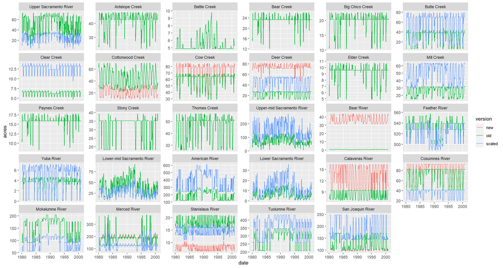

```r
new <- DSMhabitat::fr_juv %>% DSMhabitat::square_meters_to_acres()
old <- cvpiaData::fr_juv %>% DSMhabitat::square_meters_to_acres()
dimnames(old) <- dimnames(new)
juv <- expand_grid(
  watershed = factor(DSMscenario::watershed_labels,
                     levels = DSMscenario::watershed_labels),
  month = 1:12,
  year = 1980:2000) %>%
  left_join(rear_scales) %>%
  arrange(year, month, watershed) %>%
  mutate(
    old = as.vector(old),
    new = as.vector(new),
    scaled = old * scales)

juv %>%
  transmute(watershed, date = ymd(paste(year, month, 1)), old, new, scaled) %>%
  filter(!(watershed %in% c('Sutter Bypass', 'Yolo Bypass'))) %>%
  gather(version, acres, -watershed, -date)  %>%
  ggplot(aes(date, acres, color = version)) +
  geom_line() +
  facet_wrap(~watershed, scales = 'free_y')
```

**Summary Table**: All habitat measures are in acres and rounded to the nearest acre.

```r
change <- juv %>% group_by(watershed) %>%
  summarise(mean_old_habitat = round(mean(old)),
            mean_new_habitat = round(mean(new)),
            change_in_mean_habitat = round(mean_new_habitat - mean_old_habitat),
            percent_change = round(change_in_mean_habitat/mean_old_habitat * 100),
            percent_change_in_mean_habitat = paste(percent_change, "%")
            ) %>%
  filter(change_in_mean_habitat != 0, watershed != "Merced River") %>%
  select(-percent_change)

DT::datatable(change, option=list(columnDefs=list(list(targets=3:5, class="dt-right"))))
```

|  | watershed | mean_old_habitat | mean_new_habitat | change_in_mean_habitat | percent_change_in_mean_habitat |
| --- | --- | --- | --- | --- | --- |
| 1 | Cottonwood Creek | 45 | 21 | -24 | -53 % |
| 2 | Cow Creek | 59 | 73 | 14 | 24 % |
| 3 | Deer Creek | 22 | 75 | 53 | 241 % |
| 4 | Bear River | 0 | 36 | 36 | Inf % |
| 5 | Calaveras River | 8 | 14 | 6 | 75 % |
| 6 | Cosumnes River | 69 | 78 | 9 | 13 % |
| 7 | Stanislaus River | 17 | 8 | -9 | -53 % |
| 8 | San Joaquin River | 127 | 125 | -2 | -2 % |

#### Explanation of Habitat Changes:

- **Cottonwood Creek**: QA/QCd original data and redid scaling/wua conversion because initial estimate was too high
- **Cow Creek**: Increased Salmonid habitat extent to include north cow creek
- **Deer Creek**: New HSI derived habitat data
- **Bear River**: Data Updated. Original data used was from `IFIMWUA.xlsx`. Data was updated to `'data-raw/watershed/bear_river/data/updated_bear_river_instream.csv'` also provided by Mark Gard.
- **Calaveras River** Data Updated. Original data used was from `IFIMWUA.xlsx`. Data was updated to `"data-raw/watershed/calaveras/data/calaveras.csv"`
- **Cosumnes River**: Based on combination of Calaveras and Mokelume Rivers (Change in Calaveras caused change in Cosumnes)
- **Stanislaus River**: Original habitat data was only using already aggregated data from `IFIMWUA.xlsx` (`I4:N60`) which was not scaled by reach length. We updated the data to scale in each reach depending on length by reading in each reach separately, scale habitat in each reach according to reach length, and then adding all reaches together.
- **San Joaquin River**: Based on combination of Merced, Stanislaus, and Toulumne Rivers (Change in Stanislaus caused change in San Joaquin)

## Floodplain Habitat

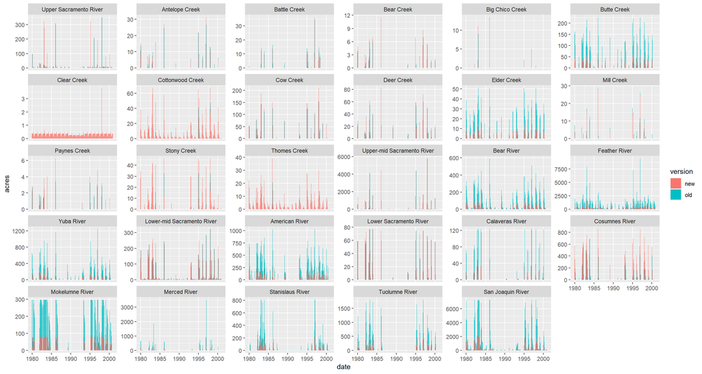

```r
new <- DSMhabitat::fr_fp %>% DSMhabitat::square_meters_to_acres()
old <- cvpiaData::fr_fp %>% DSMhabitat::square_meters_to_acres()
dimnames(old) <- dimnames(new)
fp <- expand_grid(
  watershed = factor(DSMscenario::watershed_labels,
                     levels = DSMscenario::watershed_labels),
  month = 1:12,
  year = 1980:2000) %>%
  arrange(year, month, watershed) %>%
  mutate(
    old = as.vector(old),
    new = as.vector(new))
fp %>%
  transmute(watershed, date = ymd(paste(year, month, 1)), old, new) %>%
  filter(!(watershed %in% c('Sutter Bypass', 'Yolo Bypass'))) %>%
  gather(version, acres, -watershed, -date)  %>%
  ggplot(aes(date, acres, fill = version)) +
  geom_col(position = 'dodge') +
  facet_wrap(~watershed, scales = 'free_y')
```

**Summary Table**: All habitat measures are in acres and rounded to the nearest acre.

```r
change <- fp %>% group_by(watershed) %>%
  summarise(mean_old_habitat = round(mean(old)),
            mean_new_habitat = round(mean(new)),
            change_in_mean_habitat = round(mean_new_habitat - mean_old_habitat),
            percent_change = round(change_in_mean_habitat/mean_old_habitat * 100),
            percent_change_in_mean_habitat = paste(percent_change, "%")
            ) %>%
  filter(change_in_mean_habitat != 0) %>%
  select(-percent_change)

DT::datatable(change, option=list(columnDefs=list(list(targets=3:5, class="dt-right"))))
```

|  | watershed | mean_old_habitat | mean_new_habitat | change_in_mean_habitat | percent_change_in_mean_habitat |
| --- | --- | --- | --- | --- | --- |
| 1 | Butte Creek | 28 | 8 | -20 | -71 % |
| 2 | Cottonwood Creek | 1 | 6 | 5 | 500 % |
| 3 | Elder Creek | 7 | 2 | -5 | -71 % |
| 4 | Stony Creek | 1 | 3 | 2 | 200 % |
| 5 | Thomes Creek | 0 | 3 | 3 | Inf % |
| 6 | Bear River | 69 | 19 | -50 | -72 % |
| 7 | Feather River | 803 | 217 | -586 | -73 % |
| 8 | Yuba River | 107 | 29 | -78 | -73 % |
| 9 | American River | 147 | 40 | -107 | -73 % |
| 10 | Calaveras River | 10 | 3 | -7 | -70 % |

[output cut: 6 more lines]

#### Explanation of Habitat Changes:

- **Cottonwood Creek**: Originally was using google earth derived wetted channel area of 250 which is too big. Updated to used wetted channel area that mark gard developed.
- **Calaveras River** Scaled from a Tuolumne River flow to floodplain area relationship (Change in Tuolumne caused change in Calaveras)
- **Cosumnes River**: Data updated. Flow Floodplain area relationship based on a 1-D HEC-RAS hydraulic model [CVPIA Annual Progress Report Fiscal Year 2019](https://cvpiahabitat-r-package.s3.us-west-2.amazonaws.com/cvpia-sit-model-inputs/CVPIA+Annual+Progress+Report+Fiscal+Year+2019.pdf)
- **Stony Creek, Thomes Creek**: Scaled from a Cottonwood Creek flow to floodplain area relationship (Change in Cottonwood caused change in Stony)
- For the following rivers habitat suitability was not applied in the original model when calculating floodplain estimates. Applying suitability scales habitat by multiplying by .27. This accounts for the 73% decrease in habitat from the origional values.
  - **Yuba River**
  - **Merced River**
  - **Stanislaus River**
  - **Bear River**
  - **Butte Creek**
  - **Elder Creek**
  - **Tuolumne River**
  - **Mokelumne River**
  - **Feather River**: Additionally updated to scale as partial model.
  - **American River**: Additionally updated to scale as partial model.
  - **San Joaquin River**: Additionally updated to use scaled down areas for 45 mile river reach (divide rearing extent by 79 RM) which decrease the floodplain habitat.